# 데이터 셋 (Dataset) 다루기

`sklearn.dataset` 안에는 빌트인 (built-in) 데이터 셋들이 존재합니다. 물론 튜토리얼 진행을 위한 수준이므로, 규모가 크지는 않습니다 (Toy Dataset 이라고도 불리웁니다.)

그렇지만, mldata.org 데이터 셋은 조금 더 규모가 큰 데이터 셋을 제공하며, 온라인에서 동적으로 다운로드를 받을 수 있습니다.

이번 튜토리얼에서는 Built-in 데이터 셋을 활용하는 방법에 대해서 알아보도록 하겠습니다.

```python
import warnings

# 경고 메시지 출력 표기 생략
warnings.filterwarnings('ignore')
```

## 빌트인 (Built-in) 데이터셋 활용

### 데이터 셋의 종류

- `load_boston`: 보스톤 집값 데이터
- `load_iris`: 아이리스 붓꽃 데이터
- `load_diabetes`: 당뇨병 환자 데이터
- `load_digits`: 손글씨 데이터
- `load_linnerud`: multi-output regression 용 데이터
- `load_wine`: 와인 데이터
- `load_breast_cancer`: 위스콘신 유방암 환자 데이터

### 데이터 셋 조회

빌트인 데이터셋은 `sklearn.utils.Bunch` 라는 자료구조를 활용합니다.

**key-value** 형식으로 구성되어 있으며, 사전(dict)형 타입과 유사한 구조를 가지고 있습니다.

공통 **key**는 다음과 같습니다.

- `data`: 샘플 데이터, Numpy 배열로 이루어져 있습니다.
- `target`: Label 데이터, Numpy 배열로 이루어져 있습니다.
- `feature_names`: Feature 데이터의 이름
- `target_names`: Label 데이터의 이름
- `DESCR`: 데이터 셋의 설명
- `filename`: 데이터 셋의 파일 저장 위치 (csv)

간단한 실습으로 빌트인 데이터셋의 활용법에 대하여 알아보겠습니다.

### iris 붓꽃 데이터 로드하기

```python
from IPython.display import Image

Image(url='https://user-images.githubusercontent.com/15958325/56006707-f69f3680-5d10-11e9-8609-25ba5034607e.png')
```

```python
# iris 붓꽃 데이터 로드
from sklearn.datasets import load_iris
```

`load_iris`로 데이터 셋을 불러와서 `iris` 변수에 저장합니다.

```python
# 코드를 입력해 주세요
iris =
```

```python
iris
```

## Feature 데이터 (X)

### feature 데이터 값 조회하기

feature data는 `data` 키로 접근하여 가져올 수 있습니다.

`features` 변수에 `data`를 대입해 주세요.

```python
# 코드를 입력해 주세요
features =
```

```python
features[:5]
```

feature data 에 대한 이름은 `feature_names` 로 가져올 수 있습니다.

iris 데이터의 경우 총 **4개의 feature**를 가지고 있음을 확인할 수 있습니다.

[참고] - **sepal**: 꽃받침 - **petal**: 꽃잎

```python
feature_names = iris['feature_names']
feature_names
```

## Label 데이터 (Y)

label data는 `target` 키로 접근하여 가져올 수 있습니다.

```python
labels = iris['target']
labels
```

feature data와 마찬가지로, label 데이터도 `target_names`라는 키로 target에 대한 클래쓰 이름을 확인해 볼 수 있습니다.

## 데이터 셋을 DataFrame으로 변환

```python
import pandas as pd
```

첫번째로 `data`와 `feature_names` 키로 가져온 데이터를 활용하여 데이터 프레임을 만들어 줍니다.

```python
# 코드를 입력해 주세요
df =
df.head()
```

**[출력 결과]**

|  | sepal length (cm) | sepal width (cm) | petal length (cm) | petal width (cm) |
| --- | --- | --- | --- | --- |
| 0 | 5.1 | 3.5 | 1.4 | 0.2 |
| 1 | 4.9 | 3.0 | 1.4 | 0.2 |
| 2 | 4.7 | 3.2 | 1.3 | 0.2 |
| 3 | 4.6 | 3.1 | 1.5 | 0.2 |
| 4 | 5.0 | 3.6 | 1.4 | 0.2 |

그런 다음 `target` 데이터를 새로운 컬럼을 만들어 추가해 줍니다. 여기서 target 데이터의 column 명 임의로 지정해 주면 됩니다.

```python
# 코드를 입력해 주세요
df['target'] =
```

```python
df.head()
```

## 로드한 DataFrame 시각화

```python
import matplotlib.pyplot as plt
import seaborn as sns
```

Sepal (꽃받침)의 길이 넓이에 따른 꽃의 종류가 어떻게 다르게 나오는지 살펴보겠습니다.

```python
plt.figure(figsize=(10, 7))
sns.scatterplot(df.iloc[:, 0], df.iloc[:, 1], hue=df['target'], palette='muted')
plt.title('Sepal', fontsize=17)
plt.show()
```

[output not shown]

이번에는, Petal (꽃잎)의 길이 넓이에 따른 꽃의 종류가 어떻게 다르게 나오는지 살펴보겠습니다.

```python
plt.figure(figsize=(10, 7))
sns.scatterplot(df.iloc[:, 2], df.iloc[:, 3], hue=df['target'], palette='muted')
plt.title('Petal', fontsize=17)
plt.show()
```

[output not shown]

## 데이터 분할 (train_test_split)

기계학습에서 데이터 분할을 중요한 전처리 과정입니다.

`sklearn.model_selection`의 `train_test_split`은 클래스 이름 그대로 **학습과 검증 (혹은 테스트) 셋**을 나누어 주는 역할을 합니다.

학습 (Train) / 검증 (Validation or Test) 세트로 나누며, 검증 세트로 **과대 적합**여부를 모니터링 할 수 있습니다.

또한, 검증 세트를 활용하여 모델의 성능 평가를 진행할 수 있습니다.

**샘플 데이터** 확인

```python
df.head()
```

feature(x), label(y) 데이터를 분할 합니다.

```python
from sklearn.model_selection import train_test_split
```

`target` 변수를 제외한 나머지 컬럼은 `x`변수에 대입합니다.

```python
x = df.iloc[:, :4]
x.head()
```

`y`변수에 `df['target']`을 대입합니다.

```python
y = df['target']
y.head()
```

**주요 hyperparameter**

- `test_size`: validation set에 할당할 비율 (20% -> 0.2), 기본값 0.25
- `stratify`: 분할된 샘플의 class 갯수가 동일한 비율로 유지
- `random_state`: 랜덤 시드값
- `shuffle`: 셔플 옵션, 기본값 True

```python
x_train, x_test, y_train, y_test = train_test_split(x, y, stratify=y, test_size=0.2, random_state=123)
```

원본 **x**의 shape

```python
x.shape
```

분할된 **x**의 shape

```python
x_train.shape, x_test.shape
```

원본 **y**의 shape

```python
y.shape
```

분할된 **y**의 shape

```python
y_train.shape, y_test.shape
```

## 연습문제

wine 데이터셋을 불러와 로드 하고 데이터셋을 분할 합니다.

```python
# 와인 데이터 로드
from sklearn.datasets import load_wine
```

`wine` 변수에 `load_wine()` 결과 대입

```python
# 코드를 입력해 주세요
wine =
```

- `df` 변수에 데이터 프레임 생성
- column 지정 및 target 컬럼 생성

```python
# 코드를 입력해 주세요
df =

df.head()
```

**[출력 결과]**

|  | alcohol | malic_acid | ash | alcalinity_of_ash | magnesium | total_phenols | flavanoids | nonflavanoid_phenols | proanthocyanins | color_intensity | hue | od280/od315_of_diluted_wines | proline | target |
| --- | --- | --- | --- | --- | --- | --- | --- | --- | --- | --- | --- | --- | --- | --- |
| 0 | 14.23 | 1.71 | 2.43 | 15.6 | 127.0 | 2.80 | 3.06 | 0.28 | 2.29 | 5.64 | 1.04 | 3.92 | 1065.0 | 0 |
| 1 | 13.20 | 1.78 | 2.14 | 11.2 | 100.0 | 2.65 | 2.76 | 0.26 | 1.28 | 4.38 | 1.05 | 3.40 | 1050.0 | 0 |
| 2 | 13.16 | 2.36 | 2.67 | 18.6 | 101.0 | 2.80 | 3.24 | 0.30 | 2.81 | 5.68 | 1.03 | 3.17 | 1185.0 | 0 |
| 3 | 14.37 | 1.95 | 2.50 | 16.8 | 113.0 | 3.85 | 3.49 | 0.24 | 2.18 | 7.80 | 0.86 | 3.45 | 1480.0 | 0 |
| 4 | 13.24 | 2.59 | 2.87 | 21.0 | 118.0 | 2.80 | 2.69 | 0.39 | 1.82 | 4.32 | 1.04 | 2.93 | 735.0 | 0 |

생성한 데이터프레임 shape 확인

```python
# 코드를 입력해 주세요
```

**[출력 결과]**

```
(178, 14)
```

target의 분포 확인

```python
# 코드를 입력해 주세요
```

**[출력 결과]**

```
1    71
0    59
2    48
Name: target, dtype: int64
```

`countplot()` 으로 target의 분포 확인

```python
# 코드를 입력해 주세요
```

**[출력 결과]**

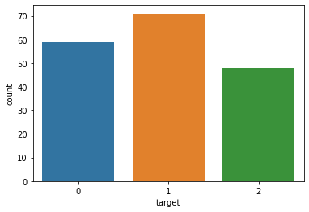

- x_train, x_test, y_train, y_test 에 분할
- test_size=0.2
- random_state=123
- `stratify` 옵션 지정

```python
# 코드를 입력해 주세요
x_train, x_test, y_train, y_test =
```

```python
# 코드검증
x_train.shape, x_test.shape
```

**[출력 결과]**

```
((142, 13), (36, 13))
```

y_train의 countplot 확인

```python
# 코드를 입력해 주세요
```

**[출력 결과]**

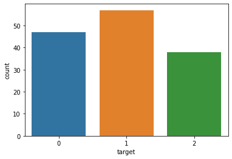

y_test countplot 확인

```python
# 코드를 입력해 주세요
```

**[출력 결과]**

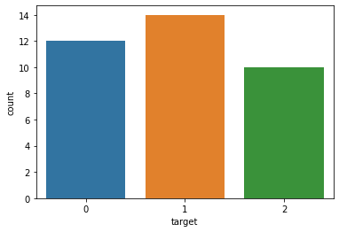